# Homework 4: Neural Networks

This assignment is due on Canvas by **11:59pm on May 21**. Your solutions to theoretical questions should be done in Markdown/Latex directly below the associated question. Your solutions to computational questions should include any specified Python code and results as well as written commentary on your conclusions. Remember that you are encouraged to discuss the problems with your instructors and classmates, but **you must write all code and solutions on your own**. Please read through the course Academic Honesty Policy [in the syllabus](https://canvas.uchicago.edu/courses/63749/assignments/syllabus).

**NOTES**:

- Do **NOT** load or use any Python packages that are not available in Anaconda (Version: 2019.07) with Python 3.9.
- Some problems with code may be autograded. If we provide a function API **do not** change it. If we do not provide a function API then you're free to structure your code however you like.
- Submit this Jupyter notebook and a PDF of your ouput to Canvas. Do not compress it using tar, rar, zip, etc.
- In this homework, we will use [PyTorch](https://pytorch.org/) to implement a classifier. Install the current stable release for PyTorch (instructions on homepage of Pytorch website). We recommend you use Anaconda for these installations in a virtual environment but you can use pip as well. For this homework, this command should be sufficient `pip3 install torch`.

It is **highly recommended** you install the CPU-only version of PyTorch if your'e unfamiliar with the process of installing CUDA libraries for these packages. If you choose to install a GPU version, ensure you're code runs without GPU support.

**Put your name here:**

**Peiyu Chen**

```python
# Test PyTorch installation
# Please do not edit this cell
import torch
import math
import pickle
import gzip
import numpy as np
import matplotlib.pylab as plt
%matplotlib inline



torch.manual_seed(1234)
```

```
<torch._C.Generator at 0x1bdbf57d370>
```

```python
print(torch.__version__)
print(torch.cuda.is_available())
```

```
2.7.0+cpu
False
```

## [26 points] Problem 1 - Single-Layer and Multilayer Perceptron Learning

### Part 1 [13 points]

Consider learning the following concepts with either a single-layer or multilayer perceptron where all hidden and output neurons utilize the *indicator* activation functions. For each of the following concepts, state whether the concept can be learned by a single-layer perceptron. Briefly justify your response by providing weights, biases, and the *indicator* activation functions if applicable:

- $\; \texttt{NOT } x_1$
- $\; x_1 \texttt{ NAND } x_2$
- $\; x_1 \texttt{ XNOR } x_2$ (output 1 when $x_1 = x_2$ and 0 otherwise)

✅ **$\; \texttt{NOT } x_1$**

**Yes**

This is a simple linear function.

Let’s set the weight $w = -1$ and bias $b = 0.5$. The perceptron computes:

$$ f(x_1) = \text{indicator}(-x_1 + 0.5) $$

So:

- If $x_1 = 0$: $f = \text{indicator}(0.5) = 1$
- If $x_1 = 1$: $f = \text{indicator}(-0.5) = 0$

✅ **$\; x_1 \texttt{ NAND } x_2$**

**Yes**

NAND is linearly separable.

Use weights $w_1 = -1$, $w_2 = -1$, and bias $b = 1.5$ The perceptron computes:

$$ f(x_1, x_2) = \text{indicator}(-x_1 - x_2 + 1.5) $$

This correctly outputs 1 for all inputs except when both $x_1 = x_2 = 1$, which matches NAND.

❌ **$\; x_1 \texttt{ XNOR } x_2$ (output 1 when $x_1 = x_2$ and 0 otherwise)**

**No**

XNOR is **not linearly separable**. We need at least one hidden layer to get it right.

Use a **multi-layer** perceptron:

- First layer detects equality (e.g., $(x_1 \wedge x_2)$ and $(\neg x_1 \wedge \neg x_2)$)
- Second layer combines them with OR

So, single-layer won’t work, but multi-layer can do it just fine.

### Part 2 [13 points]

Determine an architecture and specific values of the weights and biases in a single-layer or multilayer perceptron with *indicator* activation functions that can learn $x_1 \texttt{ XNOR } x_2$. Make a truth table of $x_1$, $x_2$, and $x_1 \texttt{ XNOR } x_2$, describe your perceptron's architecture, and state your weight matrices and bias vectors in Markdown below. Then demonstrate that your solution is correct by implementing forward propagation for your network in Python and showing that it produces the correct boolean output values for each of the four possible combinations of $x_1$ and $x_2$.

Truth Table for XNOR

| $x_1$ | $x_2$ | $x_1 \texttt{ XNOR } x_2$ |
| --- | --- | --- |
| 0 | 0 | 1 |
| 0 | 1 | 0 |
| 1 | 0 | 0 |
| 1 | 1 | 1 |

#### Perceptron Architecture

This is a **2-layer perceptron** (one hidden layer with two neurons, one output neuron). All units use the **indicator activation function**, which outputs 1 if input > 0, and 0 otherwise.

- **Hidden layer (2 neurons):**
  - Neuron 1 detects $x_1 \wedge x_2$
  - Neuron 2 detects $\neg x_1 \wedge \neg x_2$
- **Output layer (1 neuron):**
  - Performs logical OR on the hidden outputs to implement $x_1 \texttt{ XNOR } x_2$

#### Weights and Biases

**Hidden layer:**

Let input vector be $[x_1, x_2]$

Hence:

[output not shown]

**Output layer:**

- Neuron (for $h_1 \vee h_2$): $w = [1, 1],\quad b = -0.5$

```
W2 = [1, 1]
b2 = -0.5
```

```python
def indicator(x):
    return (x > 0).astype(int)

W1 = np.array([[1, 1],
               [-1, -1]])
b1 = np.array([-1.5, 0.5])
W2 = np.array([1, 1])
b2 = -0.5

X = np.array([[0, 0],
              [0, 1],
              [1, 0],
              [1, 1]])

h = indicator(X.dot(W1.T) + b1)
y = indicator(h.dot(W2) + b2)

for xi, yi in zip(X, y):
    print(f"x1={xi[0]}, x2={xi[1]} -> XNOR={yi}")
```

```
x1=0, x2=0 -> XNOR=1
x1=0, x2=1 -> XNOR=0
x1=1, x2=0 -> XNOR=0
x1=1, x2=1 -> XNOR=1
```

## [30 points] Problem 2 - Back propagation

In this problem you will gain some intuition about why training deep neural networks can be very time consuming. Consider training a chain-like neural network:

[figure not shown]

Note that this network has three weights $W^1, W^2, W^3$ and three biases $b^1, b^2,$ and $b^3$ (for this problem you can think of each parameter as a single value or as a $1 \times 1$ matrix). Suppose that each hidden and output neuron is equipped with a sigmoid activation function and the loss function is given by

$$ \ell(y, a^3) = \frac{1}{2}(y - a^3)^2 $$

where $a^3$ is the value of the activation at the output neuron and $y \in \{0,1\}$ is the true label associated with the training example.

**Note**: Superscripts on $W$'s, $b$'s, and $a$'a are being used as indices and not powers here (e.g. $a^3$ indicates the 3rd activation value, not the activation value $a$ to the 3rd power.)

### Part 1 [5 points]

Suppose each of the weights is initialized to $W^k = 1.0$ and each bias is initialized to $b^k = -0.5$. Use forward propagation to find the activities and activations associated with each hidden and output neuron for the training example $(x, y) = (0.5,0)$. Show your work.

For $(x,y)=(0.5,0)$ with all $W^k=1.0$ and $b^k=-0.5$:

1. **Layer 1**

   $$ z^1 = W^1 x + b^1 = 1\cdot0.5 + (-0.5) = 0.0, \quad a^1 = \sigma(z^1) = \frac1{1+e^{-0}} = 0.5 $$
2. **Layer 2**

   $$ z^2 = W^2 a^1 + b^2 = 1\cdot0.5 + (-0.5) = 0.0, \quad a^2 = \sigma(z^2) = 0.5 $$
3. **Output layer (Layer 3)**

   $$ z^3 = W^3 a^2 + b^3 = 1\cdot0.5 + (-0.5) = 0.0, \quad a^3 = \sigma(z^3) = 0.5 $$

So at each hidden and the output neuron, the pre-activation $z$ is $0$ and the activation $a$ is $0.5$.

### Part 2 [8 points]:

Use Backpropagation to compute the weight and bias derivatives $\partial \ell / \partial W^k$ and $\partial \ell / \partial b^k$ for $k=1, 2, 3$. Show all work.

$$ a^0 = x = 0.5,\quad z^k = 0,\;a^k=\sigma(0)=0.5\quad(k=1,2,3),\quad y=0. $$

1. **Output layer**

   $$ \frac{\partial\ell}{\partial a^3} = a^3 - y = 0.5-0 = 0.5, \qquad \sigma'(z^3)=a^3(1-a^3)=0.25 $$

   $$ \delta^3 \;=\;\frac{\partial\ell}{\partial z^3} \;=\;\frac{\partial\ell}{\partial a^3}\,\sigma'(z^3) \;=\;0.5\times0.25 \;=\;0.125 $$

   $$ \frac{\partial\ell}{\partial W^3} = \delta^3 \,a^2 = 0.125\times0.5 = 0.0625, \qquad \frac{\partial\ell}{\partial b^3} = \delta^3 = 0.125 $$
2. **Hidden layer 2**

   $$ \sigma'(z^2)=0.25,\quad W^3=1 $$

   $$ \delta^2 = W^3\,\delta^3\,\sigma'(z^2) = 1\times0.125\times0.25 = 0.03125 $$

   $$ \frac{\partial\ell}{\partial W^2} = \delta^2\,a^1 = 0.03125\times0.5 = 0.015625, \qquad \frac{\partial\ell}{\partial b^2} = \delta^2 = 0.03125 $$
3. **Hidden layer 1**

   $$ \sigma'(z^1)=0.25,\quad W^2=1 $$

   $$ \delta^1 = W^2\,\delta^2\,\sigma'(z^1) = 1\times0.03125\times0.25 = 0.0078125 $$

   $$ \frac{\partial\ell}{\partial W^1} = \delta^1\,a^0 = 0.0078125\times0.5 = 0.00390625, \qquad \frac{\partial\ell}{\partial b^1} = \delta^1 = 0.0078125 $$

### Part 3 [5 points]

Implement the following activation functions in NumPy:

- ReLU
- Sigmoid
- softmax

Please **do not use any other external libraries** for this such as sklearn.

**Note**: Assume the input `x` is a 1-dimensional numpy array with $n$ entries (i.e. `x.shape` is `(n,)`). The expected output is an array with the same shape.

```python
def relu(x):
    return np.maximum(0, x)

def sigmoid(x):
    return 1 / (1 + np.exp(-x))

def softmax(x):
    shifted = x - np.max(x)
    exp_shifted = np.exp(shifted)
    return exp_shifted / np.sum(exp_shifted)
```

```python
# random tests for checking your impementation.
from tests import tests
tests.run_test_suite('prob 2.3', (relu, sigmoid, softmax))
```

[output not shown]

### Part 4 [6 points]

Implement the following Loss functions in NumPy:

- mean squared error
- mean absolute error
- hinge

Please **do not use any other external libraries** for this such as sklearn.

**Note**: Assume that the inputs `y` and `yhat` are both 1-dimensional numpy arrays with $n$ entries. The expected output is a float.

```python
def mean_squared_error(yhat, y):
    return np.mean((yhat - y) ** 2)

def mean_absolute_error(yhat, y):
    return np.mean(np.abs(yhat - y))

def hinge_loss(yhat, y):
    return np.mean(np.maximum(0, 1 - y * yhat))
```

```python
# random tests for checking your impementation.
from tests import tests
tests.run_test_suite('prob 2.4', (mean_squared_error, mean_absolute_error))
```

[output not shown]

### Part 5 [6 points]

Explain the vanishing gradient problem. When would you observe this? Give an example.

The **vanishing gradient** problem happens when, during back-propagation in a deep network, the gradients used to update early layers become extremely small—so small that those weights barely change.

**Example:** Imagine a 30-layer MLP where every hidden unit uses a sigmoid. On a forward pass, many units saturate to outputs near 0 or 1, whose sigmoid derivative is close to 0. During back-prop, those tiny derivatives get multiplied across all 30 layers—by the time you reach layer 1 or 2, the gradient is essentially zero. As a result, the first few layers learn almost nothing, and training stalls.

## [30 Points] Problem 3 - Build a feedforward neural network in NumPy

In this problem you will implement a class representing a general feed-forward neural network that utilizes the sigmoid activation functions. Your tasks will be to implement forward propagation, prediction, back propagation, and a general train routine to learn the weights in your network via stochastic gradient descent.

The skeleton for the network class is below.

```python
import argparse
import numpy as np
import pickle
import gzip
import matplotlib.pyplot as plt


class Network:
    def __init__(self, sizes):
        self.L = len(sizes)
        self.sizes = sizes
        self.biases = [np.random.randn(n, 1) for n in self.sizes[1:]]
        self.weights = [np.random.randn(n, m) for (
            m, n) in zip(self.sizes[:-1], self.sizes[1:])]
        self.acc_train_array = []
        self.acc_test_array = []

    def g(self, z):
        """
        activation function
        """
        return sigmoid(z)

    def g_prime(self, z):
        """
        derivative of activation function
        """
        return sigmoid_prime(z)

    def forward_prop(self, a):
        """
        memory aware forward propagation for testing
        only.  back_prop implements its own forward_prop
        should take in weights and biases and return output value
        """
        for W, b in zip(self.weights, self.biases):
            a = self.g(np.dot(W, a) + b)
        return a

    def grad_cost(self, a, y):
        """
        gradient of cost function
        Assumes C(a,y) = (a-y)^2/2
        """
        return (a - y)

    def log_train_progress(self, train, test, epoch):
        """ Logs training progres.
        """
        acc_train = self.evaluate(train)
        self.acc_train_array.append(acc_train)
        if test is not None:
            acc_test = self.evaluate(test)
            self.acc_test_array.append(acc_test)
            print("Epoch {:4d}: Train {:10.5f}, Test {:10.5f}".format(
                epoch+1, acc_train, acc_test))
        else:
            print("Epoch {:4d}: Train {:10.5f}".format(
                epoch+1, acc_train))


    def SGD_train(self, train, epochs, eta, lam=0.0, verbose=True, test=None):
        """
        SGD for training parameters
        epochs is the number of epocs to run
        eta is the learning rate
        lam is the regularization parameter
        If verbose is set will print progressive accuracy updates
        If test set is provided, routine will print accuracy on test set as learning evolves
        """
        n_train = len(train)
        for epoch in range(epochs):
            perm = np.random.permutation(n_train)
            for kk in range(n_train):
                self.SGD_step(*train[perm[kk]], eta, lam)
            if verbose and epoch == 0 or (epoch + 1) % 20 == 0:
                self.log_train_progress(train, test, epoch)

    def SGD_step(self, x, y, eta, lam):
        """
        TODO: get gradients with x, y and do SGD on weights and biases

        Args:
            x: single sample features.
            y: single sample target.
            eta: learning rate.
            lam: Regularization parameter.

        """
        # compute gradients on this example
        dW_list, db_list = self.back_prop(x, y)

        # update weights with L2 decay and biases
        for i in range(len(self.weights)):
            self.weights[i] = (1 - eta * lam) * self.weights[i] - eta * dW_list[i]
            self.biases[i]  = self.biases[i] - eta * db_list[i]

    def back_prop(self, x, y):
        """
        Back propagation for derivatives of C wrt parameters
        """
        db_list = [np.zeros(b.shape) for b in self.biases]
        dW_list = [np.zeros(W.shape) for W in self.weights]

        a = x
        a_list = [a]
        z_list = [np.zeros(a.shape)]  # Pad with a placeholder so that indices match

        for W, b in zip(self.weights, self.biases):
            z = np.dot(W, a) + b
            z_list.append(z)
            a = self.g(z)
            a_list.append(a)

        # backward pass: output layer delta
        delta = self.grad_cost(a_list[-1], y) * self.g_prime(z_list[-1])
        db_list[-1] = delta
        dW_list[-1] = delta @ a_list[-2].T

        # backpropagate through hidden layers
        for l in range(2, self.L):
            z = z_list[-l]
            sp = self.g_prime(z)
            delta = (self.weights[-l+1].T @ delta) * sp
            db_list[-l] = delta
            dW_list[-l] = delta @ a_list[-l-1].T

        return dW_list, db_list

    def evaluate(self, test):
        """
        Evaluate current model on labeled test data
        """
        ctr = 0
        for x, y in test:
            yhat = self.forward_prop(x)
            ctr += yhat.argmax() == y.argmax()
        return float(ctr) / float(len(test))


def sigmoid(z, threshold=20):
    z = np.clip(z, -threshold, threshold)
    return 1.0 / (1.0 + np.exp(-z))


def sigmoid_prime(z):
    return sigmoid(z) * (1.0 - sigmoid(z))


def mnist_digit_show(flatimage, outname=None):

    import matplotlib.pyplot as plt

    image = np.reshape(flatimage, (-1, 14))

    plt.matshow(image, cmap=plt.cm.binary)
    plt.xticks([])
    plt.yticks([])
    if outname:
        plt.savefig(outname)
    else:
        plt.show()
```

### Part 1 [20 points]

Implement `SGD_step`, `back_prop`, and `forward_prop`. Use the following test cases to verify if the code is working as expected.

```python
from tests import tests
tests.run_test_suite('prob 3', Network)
```

```
TestBackPropWithoutRegularization (tests.tests.TestNetwork.TestBackPropWithoutRegularization) ... ok
TestBackPropWithRegularization (tests.tests.TestNetwork.TestBackPropWithRegularization) ... ok

----------------------------------------------------------------------
Ran 2 tests in 0.314s

OK
```

### Part 2 [10 points]

Run the above Network on MNIST Dataset and report the following (feel free to experiment with different learning rates).

- Change the hidden layer dimensions and experiment with these values: [5, 10, 20].
- Plot accuracies of different hidden layer dimensions vs. epochs for both training and testing.
- Explain the effect of hidden layer dimension on performance.

**Note:** Accuracies are stored in `self.acc_train_array` and `self.acc_test_array` if `verbose` is `True`.

```python
location = './data/tinyMNIST.pkl.gz'
f = gzip.open(location, 'rb')
u = pickle._Unpickler(f)
u.encoding = 'latin1'
train, test = u.load()
input_dimensions = len(train[0][0])
output_dimensions = len(train[0][1])
print('Number of Input Features: ', input_dimensions)
print('Number of Output classes: ', output_dimensions)

nns = []
for hidden_layer_dimensions in [5, 10, 20]:
    print('\nHidden Layer Dimensions: ', hidden_layer_dimensions)
    nn = Network([input_dimensions, hidden_layer_dimensions, output_dimensions])
    nns.append(nn)
    nn.SGD_train(train, epochs=200, eta=0.1, lam=0.0001, verbose=True, test=test)
```

```
Number of Input Features:  196
Number of Output classes:  10

Hidden Layer Dimensions:  5
Epoch    1: Train    0.15726, Test    0.16567
Epoch   20: Train    0.81753, Test    0.73349
Epoch   40: Train    0.87635, Test    0.79392
Epoch   60: Train    0.88756, Test    0.79832
Epoch   80: Train    0.88956, Test    0.80152
Epoch  100: Train    0.89116, Test    0.79952
Epoch  120: Train    0.89836, Test    0.80072
Epoch  140: Train    0.89476, Test    0.79472
Epoch  160: Train    0.89156, Test    0.80112
Epoch  180: Train    0.89636, Test    0.79752
Epoch  200: Train    0.90036, Test    0.79952

Hidden Layer Dimensions:  10
Epoch    1: Train    0.26371, Test    0.26371
Epoch   20: Train    0.90996, Test    0.83954
Epoch   40: Train    0.93637, Test    0.85914
Epoch   60: Train    0.94078, Test    0.86435
Epoch   80: Train    0.94638, Test    0.86234
Epoch  100: Train    0.94478, Test    0.86234
Epoch  120: Train    0.94838, Test    0.86154
Epoch  140: Train    0.94838, Test    0.86795
Epoch  160: Train    0.95238, Test    0.86635
Epoch  180: Train    0.94838, Test    0.86715
Epoch  200: Train    0.94718, Test    0.86515

Hidden Layer Dimensions:  20
Epoch    1: Train    0.46339, Test    0.37615
Epoch   20: Train    0.92037, Test    0.84834
Epoch   40: Train    0.94118, Test    0.86675
Epoch   60: Train    0.95078, Test    0.87475
Epoch   80: Train    0.95598, Test    0.87115
Epoch  100: Train    0.95518, Test    0.87515
Epoch  120: Train    0.95998, Test    0.88275
Epoch  140: Train    0.96158, Test    0.87835
Epoch  160: Train    0.96038, Test    0.88355
Epoch  180: Train    0.96238, Test    0.88035
Epoch  200: Train    0.96359, Test    0.88275
```

Plot training and testing accuracies below for each configuration. Use solid lines for testing accuracy, and dotted lines for train accuracy (`ls='dashed'`).

Be sure to label your lines and match colors accordingly.

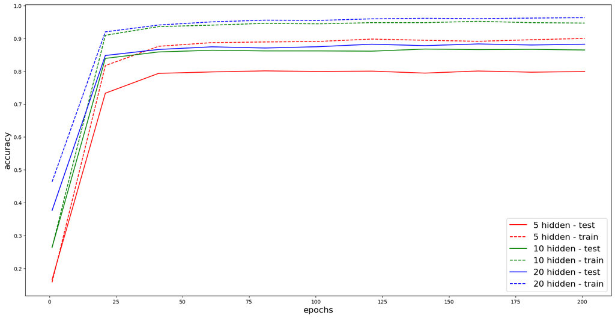

```python
fig, ax = plt.subplots(nrows=1, ncols=1, figsize=(20,10))
epochs_array = [i for i in range(1, 220, 20)]

# after: fig, ax = plt.subplots(...) and epochs_array = [...]
colors = ['r', 'g', 'b']
hidden_dims = [5, 10, 20]

# Plot test (solid) and train (dashed) for each hidden size
for idx, nn in enumerate(nns):
    train_acc = nn.acc_train_array
    test_acc  = nn.acc_test_array
    dim       = hidden_dims[idx]
    ax.plot(epochs_array, test_acc,
            label=f"{dim} hidden - test",   color=colors[idx], ls='solid')
    ax.plot(epochs_array, train_acc,
            label=f"{dim} hidden - train",  color=colors[idx], ls='dashed')

ax.legend(loc="lower right", fontsize=16)
ax.set_xlabel("epochs", fontsize=16)
ax.set_ylabel("accuracy", fontsize=16)
plt.show()
```

Give your explanation below.

Larger hidden‐layer dimensions give the network more capacity to fit the MNIST patterns, and we see that directly in both the train and test curves:

- **5 hidden units** – Converges more slowly and tops out around 88–90 % train accuracy and only ~80 % on test. – This underfitting gap shows 5 units aren’t enough to capture the digit variability.
- **10 hidden units** – Fits much faster (by epoch 20 it’s already above 90 % train / 84 % test) and plateaus around 95 % train / 86–87 % test. – Clearly better than 5 units, but still leaves some systematic error on test.
- **20 hidden units** – Reaches ~96 % train and ~88 % test by epoch 200, the best of the three. – More parameters let it model subtler features and generalize slightly better (with our modest L2 regularization).

## [14 points] Problem 4 - Tensors and Autograd.

In this problem, we will demonstrate the benefits of PyTorch's Autograd mechanics by converting your implementation from Problem 3 to utilize PyTorch Tensors. This problem is not meant to be difficult, rather it should be quite simple once you've done Problem 3.

Note that there are other ways to go about this. Here, we are keeping things as close to NumPy as possible on purpose to show what's going on behind the scenes. Take a moment to look through our modifications to get an understanding of the differences. In the comments, we'll make notes of native torch functions that perform the same operations.

Here, SGD is implemented manually to show you what's going on behind the scenes, but usually you'd use [`torch.optim.SGD`](https://pytorch.org/docs/stable/optim.html#torch.optim.SGD). For future reference, the `weight_decay` parameter implements L2 normalization.

Before we move forward, let's cover a couple of points on notation.

Just as it's best practice to do `import numpy as np`, PyTorch has best practices for imports as well:

```
import torch
import torch.nn as nn
import torch.nn.functional as F
```

You'll find that many of the functions you've been learning in NumPy have direct translations in PyTorch. The documentation can be found [here](https://pytorch.org/docs/stable/index.html) and is very user friendly, but we'll cover a few notable differences.

- The numpy parameter `axis` becomes `dim` in PyTorch.
- Tensors have [view](https://pytorch.org/docs/stable/tensor_view.html) operations, which avoid copying data unnecasarily. Use these instead of `reshape()`.
- Using `torch.from_numpy()` also avoids copying data stored in `numpy` arrays.
- Numpy interprets `np.dot()` of 2D matrices as matrix multiplication. Pytorch does not have this behaviour, see instead [`torch.matmul()`](https://pytorch.org/docs/stable/generated/torch.matmul.html?highlight=matmul#torch.matmul)
- PyTorch uses trailing underscores such as `torch.add_()` to denote in-place operations. As an example, the following operations are equivilent:

```
x = x + y
x = torch.add(x, y)
x.add_(y)
```

You're likely to see these operations when randomly initializing Tensors, or filling a tensor with zeros:

```
torch.nn.init.uniform_(x)
x.zero_()
```

Now onto the problem, your tasks are as follows:

1. Modify `forward_prop` to work on PyTorch Tensors.
2. Modify `SGD_step` to work on PyTorch Tensors. This is easier than it sounds, since with PyTorch we don't have to worry about calculating gradients manually.

```python
import torch


class TorchNetwork(Network):
    def __init__(self, sizes, keep_prob=-1):
        super().__init__(sizes)

        # Convert your weights and biases to Tensors.
        # The flag requires_grad=True tells PyTorch to track gradients for us.
        self.biases = [torch.tensor(b, requires_grad=True) for b in self.biases]
        self.weights = [torch.tensor(w, requires_grad=True) for w in self.weights]


    def g(self, z):
        """ Activation function
            Could also use torch.sigmoid(z)
        """
        return sigmoid_torch(z)

    def forward_prop(self, a):
        """ Memory aware forward propagation.
            Now this is for both training and testing.

        """
        for W, b in zip(self.weights, self.biases):
            a = self.g(W.matmul(a) + b)
        return a

    def cost(self, a, y):
        """ Cost function, same as F.mse_loss()
        """
        return ((a - y)**2).mean()


    def SGD_step(self, x, y, eta, lam):
        """
            Performs a single step of SGD on weights and biases

        Args:
            x: single sample features.
            y: single sample target.
            eta: learning rate.
            lam: Regularization parameter.

        """

        # Zero out the old gradients if they exist.
        # Would be optim.zero_grad() if we were using an optimizer.
        for p in (*self.weights, *self.biases):
            if p.grad is not None:
                p.grad.detach_()
                p.grad.zero_()

        # TODO:
        # (1) perform forward propogation
        a_out = self.forward_prop(x)
        # (2) use the loss fuction to calculate loss
        loss = self.cost(a_out, y)
        # (3) perform backpropogation
        loss.backward()

        # Perform sgd update
        # Would be optimizer.step()
        with torch.no_grad():
            # l2 regularization on weights only.
            for p in self.weights:
                p.grad.add_(p, alpha=lam)
            # sgd update.
            for p in (*self.weights, *self.biases):
                p.add_(p.grad, alpha=-eta)


def sigmoid_torch(z, threshold=20):
    """ Same as sigmoid before, now with torch.clamp() instead of np.clip().
        We could also just use torch.sigmoid().
    """
    z = torch.clamp(z, -threshold, threshold)
    return 1.0 / (1.0 + torch.exp(-z))
```

```python
from tests import tests
tests.run_test_suite('new prob 4', TorchNetwork)
torch. __version__
```

```
TestBackPropWithoutRegularization (tests.tests.TestNetwork.TestBackPropWithoutRegularization) ... ok
TestBackPropWithRegularization (tests.tests.TestNetwork.TestBackPropWithRegularization) ... ok

----------------------------------------------------------------------
Ran 2 tests in 1.609s

OK
```

```
'2.7.0+cpu'
```

**Acknowledgment** : Chris Ketelsen, Chenhao Tan

### Optional survey.

We are always interested in your feedback. At the end of each homework, there is a simple anonymous feedback [survey](https://docs.google.com/forms/d/e/1FAIpQLSdg1YzjFiP0Lgq5oUXc9AbcP7345RqmDjOKnLaYyKCaxoGVKg/viewform?usp=sf_link) to solicit your feedback for how to improve the course.